# Heat Equation, Crank-Nicolson Solver

### PROBLEM OVERVIEW

This document illustrates the solution of a one-dimensional diffusion equation/heat equation using a Crank-Nicolson timestepping scheme with central differencing in space. The PDE we solve is written as follows, for $ u = u(x, t)$ and $ x \in (0,1)$:

$$ u_t = \nu u_{xx}, $$$$ u(0, t) = u(1, t) = 0,$$$$ u(x, 0) = \sin(4 \pi x).$$

#### ANALYTICAL SOLUTION

$$ u(x, t) = e^{-16 \pi^2 \nu t} \sin(4 \pi x) $$

#### NUMERICAL SOLUTION

The numerical scheme for this PDE is written as follows:

$$ \frac{u_j^{n+1} - u_j^{n}}{\Delta t} = \frac{\nu}{2} \left[ \frac{u_{j+1}^{n+1} + u_{j-1}^{n+1} - 2u_{j}^{n+1}}{\Delta x^2} + \frac{u_{j+1}^{n} + u_{j-1}^{n} - 2u_{j}^{n}}{\Delta x^2} \right] $$

Here $j = {1,2,3, \cdots N_x}$ and $n = {1,2,3, \cdots N_t}$, the space and time indices, respectively. Taking into account the boundary conditions and performing some algebra, the scheme above is expressed as the matrix equation

$$ AU^{n + 1} = EU^{n}, $$

where

$$ A = \begin{bmatrix} 1 & 0 & 0 & 0 & \cdots & 0 \\ -\beta & 1+2\beta & -\beta & 0 & \cdots & 0 \\ 0 & -\beta & 1 + 2\beta & -\beta & \cdots & 0 \\ \vdots & \ddots & \ddots & \ddots & &\vdots \\ 0 & \cdots & -\beta & 1+2\beta & -\beta & 0\\0 & \cdots & 0 & -\beta & 1+2\beta & -\beta \\ 0 & \cdots & 0 & 0 & 0 & 1\end{bmatrix}, \quad E = \begin{bmatrix} 1 & 0 & 0 & 0 & \cdots & 0 \\ \beta & 1-2\beta & \beta & 0 & \cdots & 0 \\ 0 & \beta & 1 - 2\beta & \beta & \cdots & 0 \\ \vdots & \ddots & \ddots & \ddots & &\vdots \\ 0 & \cdots & \beta & 1-2\beta & \beta & 0\\0 & \cdots & 0 & \beta & 1-2\beta & \beta \\ 0 & \cdots & 0 & 0 & 0 & 1\end{bmatrix}, \quad U = \begin{bmatrix} u_1 \\ u_2 \\ u_3\\ \vdots \\ u_{N_x - 2} \\ u_{N_x - 1} \\ u_{N_x}\end{bmatrix}$$

and $ \beta = \frac{\nu \Delta t}{2 \Delta x^2}$.

The scheme above is implemented in MATLAB and has three components -- a tridiagonal matrix builder, a linear solver that uses Thomas' Algorithm, and Crank-Nicolson Solver.

#### TRIDIAGONAL MATRIX BUILDER

The function `cnb_tridiag(sub, dia, sup, mat_size)` builds a square tridiagonal matrix like the ones above, where the sub-diagonal, diagonal, and super-diagonal elements are each composed of the same element.

```matlab
%%file cnb_tridiag.m

function [M] = cnb_tridiag(sub, dia, sup, mat_size)

M = diag(dia*ones(1,mat_size)) + diag(sub*ones(1, mat_size-1), -1) + diag(sup*ones(1,mat_size-1), 1);

end
```

```
Created file 'C:\Stuff\Documents\Numerical PDEs\Heat_Equation_CN\cnb_tridiag.m'.
```

#### TRIDIAGONAL MATRIX SOLVER

Solution of an $ Ax = d $ problem can be done relatively rapidly using Thomas' Algorithm, provided $ A $ is tridiagonal and diagonally dominant. Given $A$ and $d$, the function `cnb_tdma(A, d)` cheaply produces $x = A^{-1}d$. The algorithm works in two stages -- a forward sweep, and a back-substitution step.

Let $A_{i,j}$ be an element of $A$ and $d_i$ be an element of $d$, then the forward sweep is done as follows for every $i = 2,3, \cdots N$, where $N$ is the order of the matrix.

$$ A_{i,i} = A_{i,i} - \left(\frac{A_{i, i-1}}{A_{i-1,i-1}}\right) A_{i-1,i},$$$$ d_i = d_i - \left(\frac{A_{i, i-1}}{A_{i-1,i-1}}\right) d_{i-1}. $$

Back-substitution is then performed the usual way.

```matlab
%%file cnb_tdma.m

function [x] = cnb_tdma(A,d)

%% ERRORS

if (size(A,1) ~= length(d))
    disp("Sizes are inconsistent with each other!!")
    return;
end

%% ALLOCATE SOLUTION VECTOR, DEFINE VARIOUS PARAMETERS

x = zeros(size(d));
N = length(d);

%% FORWARD SWEEP

for i = 2:N
      w = A(i,i-1)/A(i-1,i-1);
      A(i,i) = A(i,i) - w*A(i-1, i);
      d(i) = d(i) - w*d(i-1);
end

%% BACK-SUBSTITUTION

x(N) = d(N)/A(N,N);

for i = N-1:-1:1
    x(i) = (d(i) - A(i,i+1)*x(i+1))/A(i,i);
end

end
```

```
Created file 'C:\Stuff\Documents\Numerical PDEs\Heat_Equation_CN\cnb_tdma.m'.
```

#### CRANK-NICOLSON SOLVER

Next comes the discretization and time-stepping of the PDE. The algorithm is implemented exactly as described in the introductory section of this document. The function `cnb_heat_equation(x_start, x_end, dx, t_start, t_end, dt, u0, nu)` requires, in order: $x_1$, $x_{N_x}$, $\Delta x$, $t_1$, $t_{N_t}$, $\Delta t$, $u(x, 0)$, and $\nu$. The initial conditions are to be input as a MATLAB function handle. Since $u(x,0)$ satisfies the boundary conditions, all that is required to enforce the boundary conditions in the numerical scheme is to modify the matrices $A$ and $E$ so that they leave the the values of $u$ unchanged on the first and last grid-points.

```matlab
%%file cnb_heat_equation.m

function [x_grid, t_grid, U] = cnb_heat_equation(x_start, x_end, dx, t_start, t_end, dt, u0, nu)

%% CHARACTERIZE THE SPACE-TIME GRID

x_grid = (x_start:dx:x_end)';
t_grid = (t_start:dt:t_end)';

Nx = length(x_grid);
Nt = length(t_grid);

%% DEFINE PARAMETERS

beta = (0.5*nu*dt)/(dx*dx);

%% ALLOCATE AND INITIALIZE SOLUTION MATRICES

U = zeros(Nx,Nt); % Numerical Solution
U(:,1) = u0(x_grid);

%% CREATE CRANK-NICOLSON METHOD MATRICES A & E

A = cnb_tridiag(-beta, 1+(2*beta), -beta, Nx);
E = cnb_tridiag(beta, 1-(2*beta), beta, Nx);

A(1,1) = 1;         E(1,1) = 1;
A(1,2) = 0;         E(1,2) = 0;
A(Nx,Nx) = 1;       E(Nx,Nx) = 1;
A(Nx,Nx-1) = 0;     E(Nx,Nx-1) = 0;

%% COMPUTE NUMERICAL SOLUTION

for i = 2:Nt

    d = E*U(:,i-1);
    U(:,i) = cnb_tdma(A,d);

end

end
```

```
Created file 'C:\Stuff\Documents\Numerical PDEs\Heat_Equation_CN\cnb_heat_equation.m'.
```

#### COMPUTING THE ANALYTICAL SOLUTION

For purposes of testing and comparison, we will frequently require an analytical solution computed over the same space and time grid as the numerical solution. It is therefore convenient to write a function to do that. Note that while all the previous functions are fairly generic -- in that they can be used to solve the heat equation with any initial condition and Dirichlet (albeit with a few modifications) boundary conditions, this function is specific to the present problem.

```matlab
%%file heat_equation_ana.m

function [Ua] = heat_equation_ana(x_grid, t_grid, nu)

%% CHARACTERIZE THE SPACE-TIME GRID

Nx = length(x_grid);
Nt = length(t_grid);

%% ALLOCATE AND INITIALIZE SOLUTION MATRICES

Ua = zeros(Nx,Nt); % Analytical Solution
Ua(:,1) = sin(4*pi*x_grid);

%% COMPUTE ANALYTICAL SOLUTION

for i = 2:Nt

    Ua(:,i) = exp(-16*pi*pi*nu*t_grid(i))*Ua(:,1);

end

end
```

```
Created file 'C:\Stuff\Documents\Numerical PDEs\Heat_Equation_CN\heat_equation_ana.m'.
```

#### THE DIFFUSION EQUATION IN ACTION

As proof-of-concept, the diffusion equation is solved below (both numerically and analytically) for $\nu = 0.01$. The following parameters are used: $\Delta x = 0.02$, $\Delta t = 0.004$, $t_{end} = 1$. The numerical solution appears to at least visually correspond to the analytical solution.

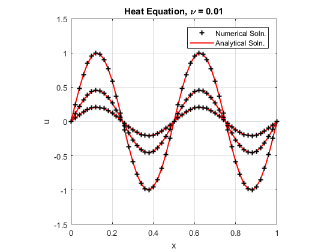

```matlab
%% SET INPUT VARIABLES

dx = 0.02;
dt = 0.004;
x_start = 0;
x_end = 1;
t_start = 0;
t_end = 1;
nu = 0.01;

u0 = @(x) sin(4*pi*x); % Initial conditions to be input as function handle.

%% CALL SOLVERS

[x_grid, t_grid, U] = cnb_heat_equation(x_start, x_end, dx, t_start, t_end, dt, u0, nu);
[Ua] = heat_equation_ana(x_grid, t_grid, nu);

%% PLOT SOLUTION
%plot inline

for i = [1, ceil(length(t_grid)/2), length(t_grid)]

    p2 = plot(x_grid, Ua(:,i), 'r-', 'linewidth', 1.5);
    hold on
    p1 = plot(x_grid, U(:,i), 'k+', 'linewidth', 1.5);
    xlabel('x');
    ylabel('u');
    title(['Heat Equation, \nu = ', num2str(nu)])
    legend([p1 p2],'Numerical Soln.', 'Analytical Soln.')
    grid on;
    xlim([x_start, x_end])
    ylim([-1.5, 1.5])
    axis square

end
```

#### DAMPING RATE COMPARISON

```matlab
%%file heat_equation_damptest.m


clear
close all
clc

%% SET INPUT VARIABLES

dx = 0.02;
dt = 0.0004;
x_start = 0;
x_end = 1;
t_start = 0;
t_end = 0.5;
nu = [0.0001, 0.01, 1]; % List of diffusion coefficients.

u0 = @(x) sin(4*pi*x);

%% ALLOCATE MAX NORM AND DAMPING RATE VECTORS

Nt = length(t_start:dt:t_end);

max_num = zeros(3, Nt); % Max norm of the numerical solution.
max_act = zeros(3, Nt); % Max norm of the analytical solution.

drate_num = zeros(3, Nt-1); % Damping rate of the numerical solution.
drate_act = zeros(3, Nt-1); % Damping rate of the analytical solution.


%% CALL SOLVERS, COMPUTE MAX NORM AND DAMPING RATE AT EVERY TIME

for k = 1:3

    [x_grid, t_grid, U] = cnb_heat_equation(x_start, x_end, dx, t_start, t_end, dt, u0, nu(k));
    [Ua] = heat_equation_ana(x_grid, t_grid, nu(k));

    for j = 1:Nt

        max_num(k,j) = max(U(:, j));  % Compute numerical Max norm.
        max_act(k,j) = max(Ua(:, j)); % Compute analytical Max norm.

    end

    drate_num(k, :) = diff(log(max_num(k, :)))/dt; % Compute numerical damping rate.
    drate_act(k, :) = diff(log(max_act(k, :)))/dt; % Compute analytical damping rate.

end

%% PLOT MAX NORM CURVES
%plot inline

figure(1)
nplot = 35;

for i = 1:3

    subplot(1,3,i)
    s2 = semilogy(t_grid, max_act(i, :), 'm-', 'linewidth', 1.5);
    hold on
    s1 = semilogy(t_grid(1:nplot:end), max_num(i, 1:nplot:end), 'k+', 'linewidth', 1.2);
    xlabel('Time')
    ylabel('Max. norm of solution')
    title(['t_{end} = ', num2str(t_end), ', \nu = ', num2str(nu(i))])
    legend([s1 s2], 'Numerical Solution', 'Analytical Solution', 'Location', 'Southwest')
    grid on
    axis square
    axis tight

end

%% PLOT DAMPING RATES OF ANALYTICAL AND NUMERICAL SOLUTION

figure(2)
nplot = 25;
end_ind = floor(Nt/3.5); % Set ending index value, for plotting convenience.

for i = 1:3

    subplot(1,3,i)
    p1 = plot(t_grid(1:end_ind), drate_act(i, 1:end_ind), 'r-', 'linewidth', 2);
    hold on
    p2 = plot(t_grid(1:nplot:end_ind), drate_num(i, 1:nplot:end_ind), 'k+', 'linewidth', 1.2);
    xlabel('Time')
    ylabel('Damping rate of solutions')
    title(['Damping Rates, \nu = ', num2str(nu(i))])
    legend([p2 p1], 'Numerical Solution', 'Analytical Solution', 'Location', 'Northwest')
    grid on
    xlim([t_grid(1), t_grid(end_ind)])
    ylim([min(drate_act(i, :))-5*nu(i), max(drate_act(i, :))+5*nu(i)])
    axis square

end
```

```
Created file 'C:\Stuff\Documents\Numerical PDEs\Heat_Equation_CN\heat_equation_damptest.m'.
```

#### DAMPING RATE COMPARISON - PLOTS

##### FIGURE 1, MAXIMUM NORMS

The plot below shows the maximum norm of the analytical (magenta line) and numerical (black crosses) as a function of time. The y-axis is logarithmically scaled, and the plots show that the numerical solution is damped at more or less the same rate as the analytical solution, as they appear to have similar slope. The slope of the analytical solution (i.e, the damping rate) is computed using the command `diff(log(max_act(i, :)))/dt`, and produces numbers that are in line with the expected analytical values.

In the third plot, the solution is damped rapidly to machine epsilon values (due to high $\nu$). This is why the crosses representing the numerical solution do not extend past a certain point.

[figure not shown]

##### FIGURE 2, DAMPING RATES

The plot below shows the damping rates of the analytical (red line) and numerical (black crosses) as a function of time. Both axes are linearly scaled, and the plots show that the damping rates are more or less constant in time, although the numerical rate is slightly different from the analytical rate.

[figure not shown]

These images are also available in the same directory under the names `Max_Norm.png` and `Damp_Rate.png`.